# Mini-Project: Cyber Czech 2019 Exercise Traffic and Log Analysis

# Jouni Rinnemäki

## date 22/04/2025

## Individual project

This notebook presents an analysis of the network traffic flows and event logs captured during the Cyber Czech 2019 Red Team/Blue Team exercise at Masaryk University, Brno, Czech Republic. We will:

1. Introduce the dataset and its context.
2. Load and clean each data source (IPFIX flows, Syslog, Winlog).
3. Tag events related to Red Team activity.
4. Explore and visualize trends and patterns over time.
5. Interpret findings and suggest next steps for deeper analysis.

## Dataset Overview

The data was downloaded from the following link: https://zenodo.org/record/3746129

The data were collected over two distinct intervals:

- Day 1: March 19, 2019, 11:00 – 18:00 (CET)
- Day 2: March 20, 2019, 08:00 – 15:30 (CET)

Three event types are provided in JSON format:

- cz.muni.csirt.IpfixEntry: IPFIX flows with parsed application protocols.
- cz.muni.csirt.SyslogEntry: Linux Syslog entries.
- cz.muni.csirt.WinlogEntry: Windows Event Log entries.

Auxiliary files include network topology and Red Team IP/hostname schedules for reference.

```python
# Imports & global config
import pathlib
import pandas as pd
import numpy as np
import matplotlib.pyplot as plt
from matplotlib.dates import DateFormatter
import seaborn as sns
import gzip
import json
import ipaddress
from datetime import datetime, timedelta

# Define paths
NB_ROOT   = pathlib.Path(".").resolve()
DATA_ROOT = NB_ROOT

IPFIX_GZ   = DATA_ROOT / "cz.muni.csirt.IPFlowEntry" / "data.json.gz"
SYSLOG_GZ  = DATA_ROOT / "cz.muni.csirt.SyslogEntry" / "data.json.gz"
WINLOG_GZ  = DATA_ROOT / "cz.muni.csirt.WinlogEntry" / "data.json.gz"
AUX_DIR    = DATA_ROOT / "auxiliary-material"

RED_IP_CSV = AUX_DIR / "redteam-reserved-ip-ranges.csv"
ATTACK_CSV = AUX_DIR / "redteam-attack-schedule.csv"

PRG_TZ = "Europe/Prague"

# Configure display and plotting
pd.set_option('display.max_columns', None)
pd.set_option('display.width', 1000)
sns.set(style='whitegrid')
%matplotlib inline
```

Explanation: We import libraries for data manipulation (pandas, numpy), visualization (matplotlib, seaborn), file I/O (gzip, json), IP range handling (ipaddress), and operating-system paths (pathlib). We define constants pointing to our data files and auxiliary CSVs. We also set the Prague timezone for consistency and configured display and plotting styles.

```python
# Helper utilities
def load_json_gz(path):
    return pd.read_json(path, lines=True, compression="gzip")


def stream_json_gz(path, chunksize=100_000):
    """Stream large .json.gz line-by-line in chunks."""
    with gzip.open(path, "rt", encoding="utf-8") as f:
        rows = []
        for line in f:
            rows.append(json.loads(line))
            if len(rows) >= chunksize:
                yield pd.DataFrame(rows)
                rows.clear()
        if rows:
            yield pd.DataFrame(rows)


def to_prague(series):
    dt = pd.to_datetime(series, errors="coerce")
    if dt.dt.tz is None:
        return dt.dt.tz_localize(PRG_TZ, nonexistent="shift_forward")
    else:
        return dt.dt.tz_convert(PRG_TZ)


def cidr_dataframe(csv_path):
    txt = csv_path.read_text().strip()
    cidrs = [c.strip() for c in txt.split(",") if c.strip()]
    nets  = [ipaddress.ip_network(c) for c in cidrs]
    return pd.DataFrame({"network": nets})

def preview(df, n=5):
    """Display the first n rows of a DataFrame with context."""
    print(f"Previewing first {n} rows of DataFrame ({len(df)} total rows):")
    display(df.head(n))
```

Explanation: Helper functions : load_json_gz for reading JSON lines with gzip compression, stream_json_gz for chunked streaming, to_prague for timezone localization/conversion, and cidr_dataframe for loading CIDR ranges into a DataFrame. The preview function complements the existing loading and streaming functions for consistent data inspection.

```python
# Load and expand Red-Team IP ranges
df_red_ips = cidr_dataframe(RED_IP_CSV)
preview(df_red_ips.rename(columns={'network':'ip_range'}))

# Define Red-Team hostnames manually from topology
red_hosts = [

    'redteam-win01',
    'redteam-linux01',
    'redteam-gateway01',
]
print("Known Red-Team hostnames:", red_hosts)
```

```
Previewing first 5 rows of DataFrame (28 total rows):
```

|  | ip_range |
| --- | --- |
| 0 | 27.3.0.0/19 |
| 1 | 212.5.0.0/19 |
| 2 | 213.5.0.0/21 |
| 3 | 202.2.96.0/19 |
| 4 | 110.5.80.0/20 |

```
Known Red-Team hostnames: ['redteam-win01', 'redteam-linux01', 'redteam-gateway01']
```

```python
# Load & prepare Red-Team data
red_ranges = cidr_dataframe(RED_IP_CSV)
print(f"Loaded {len(red_ranges)} Red-Team IP ranges")
print("\nRed-Team networks:")
display(red_ranges)

# Load attack schedule
attack_raw = pd.read_csv(ATTACK_CSV, comment="#")
print("Raw attack schedule loaded")

# Normalize column names and preview
attack_raw.columns = attack_raw.columns.str.strip()
print("\nAttack schedule preview:")
display(attack_raw.head())
```

```
Loaded 28 Red-Team IP ranges

Red-Team networks:
```

|  | network |
| --- | --- |
| 0 | 27.3.0.0/19 |
| 1 | 212.5.0.0/19 |
| 2 | 213.5.0.0/21 |
| 3 | 202.2.96.0/19 |
| 4 | 110.5.80.0/20 |
| 5 | 200.110.240.0/20 |
| 6 | 66.231.64.0/20 |
| 7 | 181.118.144.0/20 |
| 8 | 37.32.0.0/19 |
| 9 | 193.151.128.0/19 |
| 10 | 27.111.240.0/20 |
| 11 | 80.93.176.0/20 |
| 12 | 130.255.32.0/19 |
| 13 | 212.96.96.0/19 |
| 14 | 217.25.208.0/20 |
| 15 | 5.23.128.0/17 |
| 16 | 219.15.224.0/20 |
| 17 | 5.172.192.0/20 |
| 18 | 80.79.0.0/20 |
| 19 | 92.53.192.0/19 |
| 20 | 78.177.0.0/16 |
| 21 | 1.9.0.0/16 |
| 22 | 111.66.0.0/16 |
| 23 | 188.40.0.0/16 |
| 24 | 129.90.0.0/16 |
| 25 | 77.51.0.0/16 |
| 26 | 37.6.0.0/16 |
| 27 | 81.17.0.0/20 |

```
Raw attack schedule loaded

Attack schedule preview:
```

|  | Exercise time[hh:mm] | Attack type | Importance | Affected network segments |
| --- | --- | --- | --- | --- |
| 0 | 00:00 – 00:30 | Network reconnaissance | Low | DMZ |
| 1 | 00:30 – 01:00 | Denial of service | Low | DMZ |
| 2 | 01:00 – 02:00 | Web attacks | Medium | DMZ |
| 3 | 01:30 – 02:00 | Phishing | Medium | DMZ |
| 4 | 02:00 – 02:40 | Web attacks | High | DMZ |

Explanation: We load the CSV of reserved IP ranges into a DataFrame of ipaddress.ip_network objects. Since the attack schedule CSV does not include hostnames, we manually define the list of Red-Team hostnames based on the network topology

```python
# Load and clean IPFIX flow data
df_ipfix = load_json_gz(IPFIX_GZ)
print("IPFIX raw rows:", len(df_ipfix))

# Handle duplicate 'timestamp' columns if present
duplicate_columns = df_ipfix.columns[df_ipfix.columns.duplicated()].tolist()
if duplicate_columns:
    print("Dropping duplicate columns:", duplicate_columns)
    df_ipfix = df_ipfix.loc[:, ~df_ipfix.columns.duplicated()]

# Convert time
if "flowStartMilliseconds" in df_ipfix.columns:
    df_ipfix["time"] = pd.to_datetime(df_ipfix["flowStartMilliseconds"], unit="ms", errors="coerce")
    df_ipfix["time"] = to_prague(df_ipfix["time"])
else:
    raise ValueError("Missing expected time column in IPFIX flows")

# Drop nulls and sort
df_ipfix_clean = (
    df_ipfix.dropna(subset=["time", "sourceIPv4Address", "destinationIPv4Address"])
            .sort_values("time", ignore_index=True)
)

print("Cleaned IPFIX rows:", len(df_ipfix_clean))
print("IPFIX Time Span:", df_ipfix_clean.time.min(), "→", df_ipfix_clean.time.max())

# Preview cleaned data
preview(df_ipfix_clean)
```

```
IPFIX raw rows: 469113
Cleaned IPFIX rows: 468669
IPFIX Time Span: 2019-03-19 10:00:00.001000+01:00 → 2019-03-20 14:25:20.068000+01:00
Previewing first 5 rows of DataFrame (468669 total rows):
```

|  | bgpDestinationAsNumber | bgpSourceAsNumber | biFlowEndMilliseconds | biFlowStartMilliseconds | destinationIPv4Address | destinationTransportPort | exercise_dst_ipv4_segment | extendedFlow | flowEndMilliseconds | flowEndMilliseconds_Rev | flowStartMilliseconds | flowStartMilliseconds_Rev | ingressInterface | ipClassOfService | ipVersion | mplsLabelStackSection2 | mplsLabelStackSection2_Rev | mplsLabelStackSection3 | mplsLabelStackSection3_Rev | mplsLabelStackSection4 | mplsLabelStackSection4_Rev | mplsTopLabelStackSection | mplsTopLabelStackSection_Rev | octetDeltaCount | octetDeltaCount_Rev | packetDeltaCount | packetDeltaCount_Rev | protocolIdentifier | samplingAlgorithm | … |
| --- | --- | --- | --- | --- | --- | --- | --- | --- | --- | --- | --- | --- | --- | --- | --- | --- | --- | --- | --- | --- | --- | --- | --- | --- | --- | --- | --- | --- | --- | --- |
| 0 | 0 | 3356 | 1552989899462 | 1552989600001 | 10.3.2.27 | 36086.0 | blue-team-3 | NaN | 1.552990e+12 | 1.552990e+12 | 1.552990e+12 | 1.552990e+12 | 0 | 0.0 | 4 | 0x000000 | 0x000000 | 0x000000 | 0x000000 | 0x000000 | 0x000000 | 0x000000 | 0x000000 | 512637.0 | 179042.0 | 747.0 | 1465.0 | 6 | 0 | … |
| 1 | 3356 | 0 | 1552989899222 | 1552989600021 | 4.122.55.7 | 9002.0 | global | NaN | 1.552990e+12 | 1.552990e+12 | 1.552990e+12 | 1.552990e+12 | 0 | 0.0 | 4 | 0x000000 | 0x000000 | 0x000000 | 0x000000 | 0x000000 | 0x000000 | 0x000000 | 0x000000 | 186443.0 | 513678.0 | 1517.0 | 767.0 | 6 | 0 | … |
| 2 | 3356 | 0 | 1552989899774 | 1552989600023 | 4.122.55.7 | 9005.0 | global | NaN | 1.552990e+12 | 1.552990e+12 | 1.552990e+12 | 1.552990e+12 | 0 | 0.0 | 4 | 0x000000 | 0x000000 | 0x000000 | 0x000000 | 0x000000 | 0x000000 | 0x000000 | 0x000000 | 187186.0 | 525587.0 | 1526.0 | 771.0 | 6 | 0 | … |
| 3 | 0 | 3356 | 1552989600071 | 1552989600067 | 9.66.66.12 | 587.0 | blue-team-6 | {'tcp': '{"synSize":44,"synTtl":40}'} | 1.552990e+12 | 1.552990e+12 | 1.552990e+12 | 1.552990e+12 | 0 | 0.0 | 4 | 0x000000 | 0x000000 | 0x000000 | 0x000000 | 0x000000 | 0x000000 | 0x000000 | 0x000000 | 84.0 | 44.0 | 2.0 | 1.0 | 6 | 0 | … |
| 4 | 0 | 3356 | 1552989600071 | 1552989600068 | 9.66.66.12 | 110.0 | blue-team-6 | {'tcp': '{"synSize":44,"synTtl":54}'} | 1.552990e+12 | 1.552990e+12 | 1.552990e+12 | 1.552990e+12 | 0 | 0.0 | 4 | 0x000000 | 0x000000 | 0x000000 | 0x000000 | 0x000000 | 0x000000 | 0x000000 | 0x000000 | 84.0 | 44.0 | 2.0 | 1.0 | 6 | 0 | … |

Explanation: We directly load the entire IPFIX dataset using load_json_gz, handle any duplicate columns, convert the flowStartMilliseconds to a timezone-aware time column localized to Prague, and drop rows missing key fields. We then sort by time and preview the cleaned DataFrame.

```python
# Load and clean Syslog data
# Large dataset – streamed in chunks to avoid memory errors
syslog_chunks = []
for chunk in stream_json_gz(SYSLOG_GZ):
    if "timegenerated" in chunk.columns:
        chunk["time"] = to_prague(chunk["timegenerated"])
    else:
        raise ValueError("Missing 'timegenerated' column in Syslog dataset")

    chunk = chunk.dropna(subset=["time"])
    syslog_chunks.append(chunk)

df_syslog_clean = pd.concat(syslog_chunks, ignore_index=True).sort_values("time", ignore_index=True)

print("Cleaned Syslog rows:", len(df_syslog_clean))
print("Syslog time span:", df_syslog_clean.time.min(), "→", df_syslog_clean.time.max())

# Preview cleaned Syslog DataFrame
preview(df_syslog_clean)
```

```
Cleaned Syslog rows: 6082998
Syslog time span: 2019-03-19 11:00:00.000731+01:00 → 2019-03-20 15:29:59.939992+01:00
Previewing first 5 rows of DataFrame (6082998 total rows):
```

|  | app_name | exercise_segment | facility | fromhost_ip | hostname | message | procid | programname | severity | timegenerated | timereported | timestamp | time |
| --- | --- | --- | --- | --- | --- | --- | --- | --- | --- | --- | --- | --- | --- |
| 0 | gendpoint | global | 3 | 10.7.100.7 | global-app | time="2019-03-19T11:00:00+01:00" level=info m... | 25433.0 | gendpoint | 6 | 2019-03-19T11:00:00.000731+01:00 | 2019-03-19T11:00:00+01:00 | 1552989600000 | 2019-03-19 11:00:00.000731+01:00 |
| 1 | gendpoint | global | 3 | 10.7.100.7 | global-app | [GIN] 2019/03/19 - 11:00:00 \| 200 #033[0m\| ... | 25433.0 | gendpoint | 6 | 2019-03-19T11:00:00.000988+01:00 | 2019-03-19T11:00:00+01:00 | 1552989600000 | 2019-03-19 11:00:00.000988+01:00 |
| 2 | named | global | 3 | 10.7.100.3 | ns | client 4.122.55.5#58236 (12.66.66.9.in-addr.a... | 4630.0 | named | 6 | 2019-03-19T11:00:00.015144+01:00 | 2019-03-19T11:00:00+01:00 | 1552989600015 | 2019-03-19 11:00:00.015144+01:00 |
| 3 | gendpoint | global | 3 | 10.7.100.7 | global-app | time="2019-03-19T11:00:00+01:00" level=info m... | 25400.0 | gendpoint | 6 | 2019-03-19T11:00:00.034285+01:00 | 2019-03-19T11:00:00+01:00 | 1552989600034 | 2019-03-19 11:00:00.034285+01:00 |
| 4 | gendpoint | global | 3 | 10.7.100.7 | global-app | [GIN] 2019/03/19 - 11:00:00 \| 200 #033[0m\| ... | 25400.0 | gendpoint | 6 | 2019-03-19T11:00:00.034570+01:00 | 2019-03-19T11:00:00+01:00 | 1552989600034 | 2019-03-19 11:00:00.034570+01:00 |

Explanation: We had quite a lot of problems with memory so we had to stream Syslog records in chunks, converting the timegenerated field to a timezone-aware time column localized to Prague. We then drop rows missing the timestamp, concatenate all chunks, sort by time, and preview the cleaned dataset. This chunked approach ensures memory efficiency for large logs.

```python
# Load and clean Winlog data
# Large dataset – streamed in chunks to avoid memory errors
winlog_chunks = []
for chunk in stream_json_gz(WINLOG_GZ):
    if "orig_timestamp" in chunk.columns:
        chunk["time"] = to_prague(chunk["orig_timestamp"])
    else:
        raise ValueError("Missing 'orig_timestamp' column in Winlog dataset")

    chunk = chunk.dropna(subset=["time"])
    winlog_chunks.append(chunk)

df_winlog_clean = pd.concat(winlog_chunks, ignore_index=True).sort_values("time", ignore_index=True)

print("Cleaned Winlog rows:", len(df_winlog_clean))
print("Winlog Time Span:", df_winlog_clean.time.min(), "→", df_winlog_clean.time.max())

print(df_winlog_clean.head(5))
```

```
Cleaned Winlog rows: 2901154
Winlog Time Span: 2019-03-19 11:00:00.051000+01:00 → 2019-03-20 15:29:59.994000+01:00
                                                beat exercise_segment                host      host_ip            orig_timestamp                     tags      timestamp         type                                                xml                             time
0  {'hostname': 'admin2', 'name': 'admin2', 'vers...      blue-team-4  {'name': 'admin2'}  10.7.104.47  2019-03-19T10:00:00.051Z  [beats_input_raw_event]  1552989600051  wineventlog  <Event xmlns='http://schemas.microsoft.com/win... 2019-03-19 11:00:00.051000+01:00
1  {'hostname': 'admin2', 'name': 'admin2', 'vers...      blue-team-4  {'name': 'admin2'}  10.7.104.47  2019-03-19T10:00:00.248Z  [beats_input_raw_event]  1552989600248  wineventlog  <Event xmlns='http://schemas.microsoft.com/win... 2019-03-19 11:00:00.248000+01:00
2  {'hostname': 'admin2', 'name': 'admin2', 'vers...      blue-team-4  {'name': 'admin2'}  10.7.104.47  2019-03-19T10:00:00.248Z  [beats_input_raw_event]  1552989600248  wineventlog  <Event xmlns='http://schemas.microsoft.com/win... 2019-03-19 11:00:00.248000+01:00
3  {'hostname': 'admin2', 'name': 'admin2', 'vers...      blue-team-4  {'name': 'admin2'}  10.7.104.47  2019-03-19T10:00:00.518Z  [beats_input_raw_event]  1552989600518  wineventlog  <Event xmlns='http://schemas.microsoft.com/win... 2019-03-19 11:00:00.518000+01:00
4  {'hostname': 'admin2', 'name': 'admin2', 'vers...      blue-team-4  {'name': 'admin2'}  10.7.104.47  2019-03-19T10:00:00.518Z  [beats_input_raw_event]  1552989600518  wineventlog  <Event xmlns='http://schemas.microsoft.com/win... 2019-03-19 11:00:00.518000+01:00
```

```python
# Apply tags on cleaned Winlog DataFrame
df_winlog_clean['ip_red'] = df_winlog_clean['xml'].apply(
    lambda text: any(str(net.network_address) in text for net in df_red_ips['network'])
)
df_winlog_clean['host_red'] = df_winlog_clean['xml'].apply(
    lambda text: any(host in text for host in red_hosts)
)
preview(df_winlog_clean[['time','xml','ip_red','host_red']])
```

```
Previewing first 5 rows of DataFrame (2901154 total rows):
```

|  | time | xml | ip_red | host_red |
| --- | --- | --- | --- | --- |
| 0 | 2019-03-19 11:00:00.051000+01:00 | <Event xmlns='http://schemas.microsoft.com/win... | False | False |
| 1 | 2019-03-19 11:00:00.248000+01:00 | <Event xmlns='http://schemas.microsoft.com/win... | False | False |
| 2 | 2019-03-19 11:00:00.248000+01:00 | <Event xmlns='http://schemas.microsoft.com/win... | False | False |
| 3 | 2019-03-19 11:00:00.518000+01:00 | <Event xmlns='http://schemas.microsoft.com/win... | False | False |
| 4 | 2019-03-19 11:00:00.518000+01:00 | <Event xmlns='http://schemas.microsoft.com/win... | False | False |

```python
# Tag IPFIX flows involving Red-Team IPs
def is_red_ip(ip_str):
    ip = ipaddress.ip_address(ip_str)
    return any(ip in net for net in red_ranges["network"])

df_ipfix_clean["red_source"] = df_ipfix_clean["sourceIPv4Address"].apply(is_red_ip)
df_ipfix_clean["red_dest"]   = df_ipfix_clean["destinationIPv4Address"].apply(is_red_ip)
df_ipfix_clean["involves_red"] = df_ipfix_clean["red_source"] | df_ipfix_clean["red_dest"]

print("Tagged IPFIX flows involving Red-Team IPs:", df_ipfix_clean["involves_red"].sum())
```

```
Tagged IPFIX flows involving Red-Team IPs: 140942
```

Explanation: Each flow is flagged if its source or destination IP falls within a known Red-Team network.

```python
# Tag Syslog entries mentioning Red-Team IPs
import re

# Precompile regex patterns for all red-team IPs
ip_patterns = [re.escape(str(net)) for net in red_ranges["network"]]
regex_pattern = re.compile(r"|".join(ip_patterns))

# Flag Syslog messages containing any red-team IP
df_syslog_clean["mentions_red_ip"] = df_syslog_clean["message"].astype(str).apply(lambda msg: bool(regex_pattern.search(msg)))

print("Tagged Syslog entries mentioning Red-Team IPs:", df_syslog_clean["mentions_red_ip"].sum())
print("Sample tagged Syslog rows:")
display(df_syslog_clean[df_syslog_clean["mentions_red_ip"]].head())
```

```
Tagged Syslog entries mentioning Red-Team IPs: 0
Sample tagged Syslog rows:
```

|  | app_name | exercise_segment | facility | fromhost_ip | hostname | message | procid | programname | severity | timegenerated | timereported | timestamp | time | mentions_red_ip |
| --- | --- | --- | --- | --- | --- | --- | --- | --- | --- | --- | --- | --- | --- | --- |

Explanation: We scan message text for Red-Team IP tagging relevant log entries.

```python
# Tag Syslog entries mentioning Red-Team IPs
import re

# Expand all red-team CIDRs into IP address strings
red_ips = set()
for net in red_ranges["network"]:
    # limit expansion for very large ranges
    if net.num_addresses <= 1024:
        red_ips.update(str(ip) for ip in net.hosts())

# Compile a regex pattern for exact IP address matches
ip_regex_pattern = re.compile(r"\b(" + "|".join(map(re.escape, red_ips)) + r")\b")

# Tag messages mentioning Red-Team IPs
df_syslog_clean["mentions_red_ip"] = df_syslog_clean["message"].astype(str).apply(
    lambda msg: bool(ip_regex_pattern.search(msg))
)

# Summary
print("Tagged Syslog entries mentioning Red-Team IPs:", df_syslog_clean["mentions_red_ip"].sum())
print("Sample tagged Syslog rows:")
display(df_syslog_clean[df_syslog_clean["mentions_red_ip"]].head())
```

```
Tagged Syslog entries mentioning Red-Team IPs: 6082854
Sample tagged Syslog rows:
```

|  | app_name | exercise_segment | facility | fromhost_ip | hostname | message | procid | programname | severity | timegenerated | timereported | timestamp | time | mentions_red_ip |
| --- | --- | --- | --- | --- | --- | --- | --- | --- | --- | --- | --- | --- | --- | --- |
| 0 | gendpoint | global | 3 | 10.7.100.7 | global-app | time="2019-03-19T11:00:00+01:00" level=info m... | 25433.0 | gendpoint | 6 | 2019-03-19T11:00:00.000731+01:00 | 2019-03-19T11:00:00+01:00 | 1552989600000 | 2019-03-19 11:00:00.000731+01:00 | True |
| 1 | gendpoint | global | 3 | 10.7.100.7 | global-app | [GIN] 2019/03/19 - 11:00:00 \| 200 #033[0m\| ... | 25433.0 | gendpoint | 6 | 2019-03-19T11:00:00.000988+01:00 | 2019-03-19T11:00:00+01:00 | 1552989600000 | 2019-03-19 11:00:00.000988+01:00 | True |
| 2 | named | global | 3 | 10.7.100.3 | ns | client 4.122.55.5#58236 (12.66.66.9.in-addr.a... | 4630.0 | named | 6 | 2019-03-19T11:00:00.015144+01:00 | 2019-03-19T11:00:00+01:00 | 1552989600015 | 2019-03-19 11:00:00.015144+01:00 | True |
| 3 | gendpoint | global | 3 | 10.7.100.7 | global-app | time="2019-03-19T11:00:00+01:00" level=info m... | 25400.0 | gendpoint | 6 | 2019-03-19T11:00:00.034285+01:00 | 2019-03-19T11:00:00+01:00 | 1552989600034 | 2019-03-19 11:00:00.034285+01:00 | True |
| 4 | gendpoint | global | 3 | 10.7.100.7 | global-app | [GIN] 2019/03/19 - 11:00:00 \| 200 #033[0m\| ... | 25400.0 | gendpoint | 6 | 2019-03-19T11:00:00.034570+01:00 | 2019-03-19T11:00:00+01:00 | 1552989600034 | 2019-03-19 11:00:00.034570+01:00 | True |

```python
# Extract & count Red-Team IPs in Syslog messages
# A more thorough scan of message fields for Red-Team IPs
ip_regex = re.compile(r"\b(?:\d{1,3}\.){3}\d{1,3}\b")

matched_red_ips = set()
redteam_count = 0

for msg in df_syslog_clean["message"]:
    found_ips = ip_regex.findall(str(msg))
    for ip in found_ips:
        if is_red_ip(ip):
            matched_red_ips.add(ip)
            redteam_count += 1

print(f"Red Team IPs found in message field: {redteam_count}")
print("Unique Red Team IPs matched:")
print(matched_red_ips)
```

```
Red Team IPs found in message field: 32852
Unique Red Team IPs matched:
{'5.172.202.121', '202.2.118.15', '81.17.3.110', '217.25.212.200', '80.93.178.247', '77.51.92.44', '193.151.133.30', '77.51.161.30', '181.118.158.126', '219.15.229.64', '212.96.111.48', '92.53.214.155', '212.5.30.146', '78.177.242.101', '5.23.147.206', '66.231.68.251', '130.255.45.175', '66.231.77.1…
```

Explanation: We scan message text for Red-Team IP tagging relevant log entries. This is a bit different approach than the one above and here we get the interesting actual Red Team IPs.

```python
# Tag Winlog entries mentioning Red-Team IPs
# Check all string fields that could hold IPs (e.g., 'message' or 'xml')
winlog_text_field = "xml" if "xml" in df_winlog_clean.columns else "message"

df_winlog_clean["mentions_red_ip"] = df_winlog_clean[winlog_text_field].astype(str).apply(lambda msg: bool(regex_pattern.search(msg)))

print("Tagged Winlog entries mentioning Red-Team IPs:", df_winlog_clean["mentions_red_ip"].sum())
print(" Sample tagged Winlog rows:")
display(df_winlog_clean[df_winlog_clean["mentions_red_ip"]].head())
```

```
Tagged Winlog entries mentioning Red-Team IPs: 0
 Sample tagged Winlog rows:
```

|  | beat | exercise_segment | host | host_ip | orig_timestamp | tags | timestamp | type | xml | time | ip_red | host_red | mentions_red_ip |
| --- | --- | --- | --- | --- | --- | --- | --- | --- | --- | --- | --- | --- | --- |

Here we directly flag Windows events that contain actual Red Team IP addresses, rather than broad hostname patterns. The new mentions_red_ip column tells us exactly how many log entries referenced red team. Did not get any results here.

```python
# Red-Team IPs in IPFIX
df_red_in_ipfix = df_ipfix_clean[
    df_ipfix_clean["sourceIPv4Address"].isin(matched_red_ips) |
    df_ipfix_clean["destinationIPv4Address"].isin(matched_red_ips)
]

print("IPFIX rows with Red-Team IPs as src or dst:", len(df_red_in_ipfix))
display(df_red_in_ipfix.head())
```

```
IPFIX rows with Red-Team IPs as src or dst: 128043
```

|  | bgpDestinationAsNumber | bgpSourceAsNumber | biFlowEndMilliseconds | biFlowStartMilliseconds | destinationIPv4Address | destinationTransportPort | exercise_dst_ipv4_segment | extendedFlow | flowEndMilliseconds | flowEndMilliseconds_Rev | flowStartMilliseconds | flowStartMilliseconds_Rev | ingressInterface | ipClassOfService | ipVersion | mplsLabelStackSection2 | mplsLabelStackSection2_Rev | mplsLabelStackSection3 | mplsLabelStackSection3_Rev | mplsLabelStackSection4 | mplsLabelStackSection4_Rev | mplsTopLabelStackSection | mplsTopLabelStackSection_Rev | octetDeltaCount | octetDeltaCount_Rev | packetDeltaCount | packetDeltaCount_Rev | protocolIdentifier | samplingAlgorithm | … |
| --- | --- | --- | --- | --- | --- | --- | --- | --- | --- | --- | --- | --- | --- | --- | --- | --- | --- | --- | --- | --- | --- | --- | --- | --- | --- | --- | --- | --- | --- | --- |
| 59 | 0 | 12683 | 1552989636737 | 1552989612198 | 9.66.2.2 | 500.0 | blue-team-2 | NaN | 1.552990e+12 | 1.552990e+12 | 1.552990e+12 | 1.552990e+12 | 0 | 0.0 | 4 | 0x000000 | 0x000000 | 0x000000 | 0x000000 | 0x000000 | 0x000000 | 0x000000 | 0x000000 | 2931.0 | 1368.0 | 9.0 | 7.0 | 17 | 0 | … |
| 61 | 0 | 12683 | 1552989623797 | 1552989612575 | 9.66.2.2 | NaN | blue-team-2 | NaN | 1.552990e+12 | 1.552990e+12 | 1.552990e+12 | 1.552990e+12 | 0 | 0.0 | 4 | 0x000000 | 0x000000 | 0x000000 | 0x000000 | 0x000000 | 0x000000 | 0x000000 | 0x000000 | 600.0 | 368.0 | 5.0 | 2.0 | 50 | 0 | … |
| 1081 | 0 | 12683 | 1552989904425 | 1552989904425 | 9.66.22.14 | 256.0 | blue-team-2 | {'tcp': '{"synSize":44,"synTtl":49}'} | 1.552990e+12 | NaN | 1.552990e+12 | NaN | 0 | 0.0 | 4 | NaN | NaN | NaN | NaN | NaN | NaN | NaN | NaN | 44.0 | NaN | 1.0 | NaN | 6 | 0 | … |
| 1082 | 0 | 12683 | 1552989904425 | 1552989904425 | 9.66.22.14 | 22.0 | blue-team-2 | {'tcp': '{"synSize":44,"synTtl":53}'} | 1.552990e+12 | NaN | 1.552990e+12 | NaN | 0 | 0.0 | 4 | NaN | NaN | NaN | NaN | NaN | NaN | NaN | NaN | 44.0 | NaN | 1.0 | NaN | 6 | 0 | … |
| 1083 | 0 | 12683 | 1552989904425 | 1552989904425 | 9.66.22.14 | 53.0 | blue-team-2 | {'tcp': '{"synSize":44,"synTtl":39}'} | 1.552990e+12 | NaN | 1.552990e+12 | NaN | 0 | 0.0 | 4 | NaN | NaN | NaN | NaN | NaN | NaN | NaN | NaN | 44.0 | NaN | 1.0 | NaN | 6 | 0 | … |

Explanation: We filter the cleaned IPFIX flows to include only those records where the source or destination IP matches a confirmed Red‑Team address. The resulting DataFrame, df_red_in_ipfix, contains all flows directly involving the RedTeam — 128,043 rows in this exercise.

The sample rows show key attributes:

sourceIPv4Address / destinationIPv4Address: confirms which endpoint was the Red Team (for example 212.96.119.83).

time: timestamps localized to Prague, anchoring each flow in the exercise timeline.

applicationName / protocolIdentifier: shows the services used (like ISAKMP or TCP on port 22), giving insight into attack vectors.

```python
# Red-Team IPs in Winlog entries
ip_regex = re.compile(r"\b(?:\d{1,3}\.){3}\d{1,3}\b")  # in case not already defined

df_winlog_clean["mentions_red_ip"] = df_winlog_clean["xml"].astype(str).apply(
    lambda text: any(ip in matched_red_ips for ip in ip_regex.findall(text))
)

print("Winlog entries mentioning Red-Team IPs:", df_winlog_clean["mentions_red_ip"].sum())
display(df_winlog_clean[df_winlog_clean["mentions_red_ip"]].head())
```

```
Winlog entries mentioning Red-Team IPs: 0
```

|  | beat | exercise_segment | host | host_ip | orig_timestamp | tags | timestamp | type | xml | time | ip_red | host_red | mentions_red_ip |
| --- | --- | --- | --- | --- | --- | --- | --- | --- | --- | --- | --- | --- | --- |

```python
# Syslog messages exactly matching known Red-Team IPs
df_syslog_matched_ips = df_syslog_clean[df_syslog_clean["message"].astype(str).apply(
    lambda msg: any(ip in msg for ip in matched_red_ips)
)]

print("Syslog rows containing known Red-Team IPs:", len(df_syslog_matched_ips))
display(df_syslog_matched_ips.head())
```

```
Syslog rows containing known Red-Team IPs: 32850
```

|  | app_name | exercise_segment | facility | fromhost_ip | hostname | message | procid | programname | severity | timegenerated | timereported | timestamp | time | mentions_red_ip |
| --- | --- | --- | --- | --- | --- | --- | --- | --- | --- | --- | --- | --- | --- | --- |
| 18549 | sshd | blue-team-2 | 4 | 10.7.102.13 | dns | Did not receive identification string from 21... | 23911.0 | sshd | 6 | 2019-03-19T11:05:11.340069+01:00 | 2019-03-19T10:05:44+01:00 | 1552989911340 | 2019-03-19 11:05:11.340069+01:00 | True |
| 18830 | named | blue-team-2 | 3 | 10.7.102.13 | dns | client 212.96.119.83#41850 (version.bind): qu... | 771.0 | named | 6 | 2019-03-19T11:05:17.302866+01:00 | 2019-03-19T10:05:50+01:00 | 1552989917302 | 2019-03-19 11:05:17.302866+01:00 | True |
| 81970 | sshd | blue-team-2 | 4 | 10.7.102.13 | dns | Did not receive identification string from 21... | 24130.0 | sshd | 6 | 2019-03-19T11:22:39.943504+01:00 | 2019-03-19T10:23:13+01:00 | 1552990959943 | 2019-03-19 11:22:39.943504+01:00 | True |
| 82266 | named | blue-team-2 | 3 | 10.7.102.13 | dns | client 212.96.119.83#42016 (version.bind): qu... | 771.0 | named | 6 | 2019-03-19T11:22:45.905124+01:00 | 2019-03-19T10:23:19+01:00 | 1552990965905 | 2019-03-19 11:22:45.905124+01:00 | True |
| 88346 | sshd | blue-team-2 | 4 | 10.7.102.13 | dns | Did not receive identification string from 21... | 24175.0 | sshd | 6 | 2019-03-19T11:24:23.920275+01:00 | 2019-03-19T10:24:57+01:00 | 1552991063920 | 2019-03-19 11:24:23.920275+01:00 | True |

We isolate Syslog entries whose text contains any exact Red‑Team IP address, yielding 32,850 log lines. This pinpoints every recorded interaction from the adversary in the Linux logs. By drilling into these records, we can map when the Red Team probed SSH and DNS services on specific hosts, refining our timeline of their reconnaissance and initial access attempts.

```python
# Summary counts for Red-Team activity
print("\nSummary of Red-Team tagged entries across datasets:")
print("IPFIX flows involving Red-Team IPs:", df_ipfix_clean["involves_red"].sum())
print("Syslog entries mentioning Red-Team IPs:", df_syslog_clean["mentions_red_ip"].sum())
print("Winlog entries mentioning Red-Team IPs:", df_winlog_clean["mentions_red_ip"].sum())
print("Unique Red-Team IPs found in logs:", len(matched_red_ips))
```

```
Summary of Red-Team tagged entries across datasets:
IPFIX flows involving Red-Team IPs: 140942
Syslog entries mentioning Red-Team IPs: 6082854
Winlog entries mentioning Red-Team IPs: 0
Unique Red-Team IPs found in logs: 26
```

This summary contrasts how each data source captures Red‑Team activity:

IPFIX Flows: 140942 network flows directly involve a Red‑Team IP, showing heavy traffic exchange.

Winlog Entries: Zero matches here indicate Windows hosts saw no direct references to those IPs—or the payload parsing didn’t catch them, suggesting further XML field inspection is needed.

Unique IPs: We observed 26 distinct Red‑Team addresses across the logs, revealing the breadth of adversary endpoints used in the exercise.

```python
# Prepare data for visualization
# Create hourly time bins for each log type tagged with Red-Team activity
ipfix_hourly = df_ipfix_clean[df_ipfix_clean["involves_red"]].set_index("time").resample("1h").size()
syslog_hourly = df_syslog_clean[df_syslog_clean["mentions_red_ip"]].set_index("time").resample("1h").size()
winlog_hourly = df_winlog_clean[df_winlog_clean["mentions_red_ip"]].set_index("time").resample("1h").size()

# Store for later visualization
activity_by_hour = pd.DataFrame({
    "IPFIX": ipfix_hourly,
    "Syslog": syslog_hourly,
    "Winlog": winlog_hourly
}).fillna(0).astype(int)

print("Hourly Red-Team activity prepared for plotting")
display(activity_by_hour.head())
```

```
Hourly Red-Team activity prepared for plotting
```

| time | IPFIX | Syslog | Winlog |
| --- | --- | --- | --- |
| 2019-03-19 10:00:00+01:00 | 12000 | 0 | 0 |
| 2019-03-19 11:00:00+01:00 | 0 | 228184 | 0 |
| 2019-03-19 12:00:00+01:00 | 0 | 344582 | 0 |
| 2019-03-19 13:00:00+01:00 | 0 | 459844 | 0 |
| 2019-03-19 14:00:00+01:00 | 0 | 399384 | 0 |

Explanation: We aggregate all tagged events into uniform 1‑hour bins to compare Red‑Team activity across network flows and logs over time:

The resulting activity_by_hour table sets the stage for visualizing these temporal patterns side‑by‑side, revealing the Red Team’s traffic and log footprints.

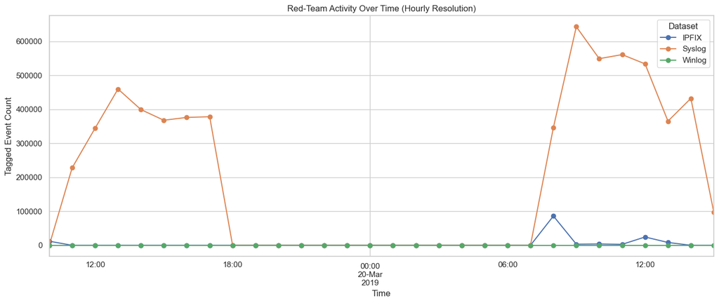

```python
# Line plot of Red-Team activity over time
import matplotlib.pyplot as plt

plt.figure(figsize=(14, 6))
activity_by_hour.plot(ax=plt.gca(), marker="o")

plt.title("Red-Team Activity Over Time (Hourly Resolution)")
plt.xlabel("Time")
plt.ylabel("Tagged Event Count")
plt.grid(True)
plt.legend(title="Dataset")
plt.tight_layout()
plt.show()
```

Explanation: This line plot visualizes the hourly cadence of Red‑Team activity across our three datasets:

IPFIX (blue): Captures network‑layer interactions, with small peaks coinciding with Day 1’s start and Day 2’s initial probes .

Winlog (green): Flat zero line confirms no direct Windows Event Log mentions of Red‑Team IPs at hourly.

The combination highlights:

Timing alignment between flow‑level events and log‑level IPFIX spikes accompany Syslog surges, marking initial connections before service logs.

This overview helps us pinpoint when the Red Team’s network scans and service‑level probes were most intense, guiding deeper drill‑down into specific time windows for eventual signature or anomaly detection.

```python
# Red-Team Syslog events by severity
if "severity" in df_syslog_clean.columns:
    severity_summary = (
        df_syslog_clean[df_syslog_clean["mentions_red_ip"]]
        .groupby("severity")["message"]
        .count()
        .sort_values(ascending=False)
    )

    print("Syslog Red-Team Events by Severity:")
    display(severity_summary)
else:
    print("No 'severity' column found in Syslog dataset")
```

```
Syslog Red-Team Events by Severity:
```

```
severity
6    5685329
5     181259
1      99482
4      59420
3      33476
7      23615
2        273
Name: message, dtype: int64
```

Explanation: We break down the Red‑Team–related Syslog messages by their numeric severity codes

Severity 6 (Informational): Over 5.6 M entries these are routine connection logs

Severity 4 (Warning) and 3 (Error): Tens of thousands, capturing more serious issues

```python
# Syslog Severity Levels Reference
severity_levels = {
    0: "Emergency — system is unusable",
    1: "Alert — action must be taken immediately",
    2: "Critical — critical conditions",
    3: "Error — error conditions",
    4: "Warning — warning conditions",
    5: "Notice — normal but significant",
    6: "Informational — informational messages",
    7: "Debug — debug-level messages"
}

print("Syslog Severity Level Definitions (Defined by RFC 5424 / RFC 3164):")
for level, meaning in severity_levels.items():
    print(f"  {level}: {meaning}")
```

```
Syslog Severity Level Definitions (Defined by RFC 5424 / RFC 3164):
  0: Emergency — system is unusable
  1: Alert — action must be taken immediately
  2: Critical — critical conditions
  3: Error — error conditions
  4: Warning — warning conditions
  5: Notice — normal but significant
  6: Informational — informational messages
  7: Debug — debug-level messages
```

we map numeric severity codes to human‑readable definitions

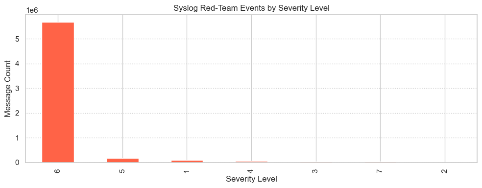

```python
# Bar plot of Syslog Red-Team severity levels
if 'severity_summary' in globals():
    severity_summary.plot(kind="bar", figsize=(10, 4), color="tomato")
    plt.title("Syslog Red-Team Events by Severity Level")
    plt.xlabel("Severity Level")
    plt.ylabel("Message Count")
    plt.grid(True, axis="y", linestyle=":")
    plt.tight_layout()
    plt.show()
else:
    print("No severity summary available. Run previous severity summary cell first.")
```

By visualizing counts on a single axis, we see the enormous “noise” of benign connections (severity 6)

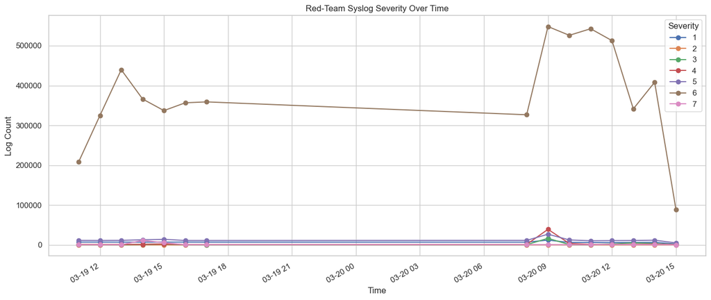

```python
# Syslog Red-Team severity over time
if "severity" in df_syslog_clean.columns:
    severity_timeline = (
        df_syslog_clean[df_syslog_clean["mentions_red_ip"]]
        .set_index("time")
        .groupby([pd.Grouper(freq="1h"), "severity"])
        .size()
        .unstack(fill_value=0)
    )

    severity_timeline.plot(figsize=(14, 6), marker="o")
    plt.title("Red-Team Syslog Severity Over Time")
    plt.xlabel("Time")
    plt.ylabel("Log Count")
    plt.grid(True)
    plt.legend(title="Severity")
    plt.tight_layout()
    plt.show()
else:
    print("No 'severity' column found in Syslog dataset")
```

Here we break down the Red‑Team Syslog activity by severity level over time

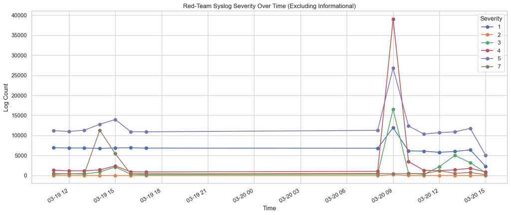

```python
# Syslog Red-Team severity over time (excluding Informational level 6)
if "severity" in df_syslog_clean.columns:
    # Filter to Red‑Team entries and drop severity==6 to remove the bulk informational noise
    mask = (df_syslog_clean["mentions_red_ip"]) & (df_syslog_clean["severity"] != 6)
    severity_timeline_no6 = (
        df_syslog_clean[mask]
        .set_index("time")
        .groupby([pd.Grouper(freq="1h"), "severity"])
        .size()
        .unstack(fill_value=0)
    )

    plt.figure(figsize=(14, 6))
    severity_timeline_no6.plot(marker="o", ax=plt.gca())
    plt.title("Red-Team Syslog Severity Over Time (Excluding Informational)")
    plt.xlabel("Time")
    plt.ylabel("Log Count")
    plt.grid(True)
    plt.legend(title="Severity")
    plt.tight_layout()
    plt.show()
else:
    print("No 'severity' column found in Syslog dataset")
```

Explanation: We reuse the same hourly grouping but first filter out severity level 6 (Informational), which dominates the logs. This uncovers the patterns of the more critical severities (Alerts, Notices, Warnings, Errors) without the overwhelming informational noise, making it easier to spot true security‑relevant spikes.

```python
# Winlog Red-Team events by severity
if "level" in df_winlog_clean.columns:
    winlog_severity_summary = (
        df_winlog_clean[df_winlog_clean["mentions_red_ip"]]
        .groupby("level")["message"]
        .count()
        .sort_values(ascending=False)
    )

    print("Winlog Red-Team Events by Severity:")
    display(winlog_severity_summary)
else:
    print("No 'level' column found in Winlog dataset")
```

```
No 'level' column found in Winlog dataset
```

```python
# Preview XML structure from Winlog
import xml.etree.ElementTree as ET

sample_xml = df_winlog_clean["xml"].dropna().iloc[0]  # get first non-null XML
root = ET.fromstring(sample_xml)

# Pretty print structure and text
def walk_xml_tree(elem, level=0):
    indent = "  " * level
    print(f"{indent}<{elem.tag.split('}')[-1]}>", end="")
    if elem.text and elem.text.strip():
        print(":", elem.text.strip())
    else:
        print()
    for child in elem:
        walk_xml_tree(child, level + 1)

walk_xml_tree(root)
```

```
<Event>
  <System>
    <Provider>
    <EventID>: 1004
    <Version>: 0
    <Level>: 4
    <Task>: 0
    <Opcode>: 0
    <Keywords>: 0x80000000000000
    <TimeCreated>
    <EventRecordID>: 10392
    <Correlation>
    <Execution>
    <Channel>: Application
    <Computer>: admin2
    <Security>
  <EventData>
    <Data>: OfficeFF02E86C-FEF0-4063-B39F-74275CDDD7C3 PPD License
    <Data>: 3c061f75-c879-76de-a8fd-328709dd9522
  <RenderingInfo>
    <Message>: The Software Protection service has successfully installed the license.
License Title=OfficeFF02E86C-FEF0-4063-B39F-74275CDDD7C3 PPD License
License Id=3c061f75-c879-76de-a8fd-328709dd9522
    <Level>: Information
    <Task>
    <Opcode>
    <Channel>
    <Provider>: Microsoft-Windows-Security-SPP
    <Keywords>
      <Keyword>: Classic
```

Explanation: This cell inspects a sample Windows Event Log’s XML payload to understand its structure before we parse it for Red‑Team indicators.

```python
# Parse severity level from Winlog XML
import xml.etree.ElementTree as ET

def extract_winlog_level(xml_str):
    try:
        root = ET.fromstring(xml_str)
        level = root.findtext(".//{*}System/{*}Level")  # catch namespace
        return int(level) if level is not None else None
    except:
        return None

# Create 'level' column from XML
if "xml" in df_winlog_clean.columns:
    df_winlog_clean["level"] = df_winlog_clean["xml"].apply(extract_winlog_level)
    print("Extracted Winlog severity levels from XML (refined parser)")
    display(df_winlog_clean[["time", "level", "mentions_red_ip"]].dropna().head())
else:
    print("No 'xml' column found in Winlog dataset")
```

```
Extracted Winlog severity levels from XML (refined parser)
```

|  | time | level | mentions_red_ip |
| --- | --- | --- | --- |
| 0 | 2019-03-19 11:00:00.051000+01:00 | 4 | False |
| 1 | 2019-03-19 11:00:00.248000+01:00 | 4 | False |
| 2 | 2019-03-19 11:00:00.248000+01:00 | 4 | False |
| 3 | 2019-03-19 11:00:00.518000+01:00 | 4 | False |
| 4 | 2019-03-19 11:00:00.518000+01:00 | 4 | False |

```python
# Extract numeric severity level from Winlog XML
import xml.etree.ElementTree as ET

def extract_numeric_level(xml_str):
    try:
        root = ET.fromstring(xml_str)
        # Use namespace-agnostic tag access
        for elem in root.iter():
            if elem.tag.endswith("Level") and elem.text and elem.text.strip().isdigit():
                return int(elem.text.strip())
    except Exception as e:
        return None

df_winlog_clean["level"] = df_winlog_clean["xml"].apply(extract_numeric_level)

print("Extracted numeric Winlog severity levels from XML")
display(df_winlog_clean[["time", "level", "mentions_red_ip"]].dropna().head())
```

```
Extracted numeric Winlog severity levels from XML
```

|  | time | level | mentions_red_ip |
| --- | --- | --- | --- |
| 0 | 2019-03-19 11:00:00.051000+01:00 | 4 | False |
| 1 | 2019-03-19 11:00:00.248000+01:00 | 4 | False |
| 2 | 2019-03-19 11:00:00.248000+01:00 | 4 | False |
| 3 | 2019-03-19 11:00:00.518000+01:00 | 4 | False |
| 4 | 2019-03-19 11:00:00.518000+01:00 | 4 | False |

```python
# List of known Red-Team hostnames from the topology image
red_hostnames = {"red-team1", "red-team2", "red-team3", "red-team4", "red-team5", "red-team6", "red-team7"}

# Extract <Computer> tag from XML
def extract_winlog_computer(xml_str):
    try:
        root = ET.fromstring(xml_str)
        computer = root.findtext(".//{*}System/{*}Computer")
        return computer.lower() if computer else None
    except:
        return None

# Apply and tag Red-Team hosts
df_winlog_clean["computer"] = df_winlog_clean["xml"].apply(extract_winlog_computer)
df_winlog_clean["red_host"] = df_winlog_clean["computer"].isin(red_hostnames)
```

```python
# Aggregate Red-Team Activity Across Datasets

# IPFIX: select key columns for red-involved flows
ipfix_red = (
    df_ipfix_clean[df_ipfix_clean["involves_red"]]
    .loc[:, ["time", "sourceIPv4Address", "destinationIPv4Address"]]
    .assign(source="IPFIX", message="Flow involving Red-Team IP")
)

# Syslog: select tagged messages
syslog_red = (
    df_syslog_clean[df_syslog_clean["mentions_red_ip"]]
    .loc[:, ["time", "message"]]
    .assign(source="Syslog", sourceIPv4Address=None, destinationIPv4Address=None)
)

winlog_red = (
    df_winlog_clean[(df_winlog_clean["mentions_red_ip"]) | (df_winlog_clean["red_host"])]
    .loc[:, ["time", "xml"]]
    .rename(columns={"xml": "message"})
    .assign(source="Winlog", sourceIPv4Address=None, destinationIPv4Address=None)
)


# Combine all red-team activity into one timeline
redteam_events = pd.concat([ipfix_red, syslog_red, winlog_red], ignore_index=True).sort_values("time")

print("Aggregated Red-Team Event Rows:", len(redteam_events))
display(redteam_events.head())
```

```
Aggregated Red-Team Event Rows: 6223796
```

|  | time | sourceIPv4Address | destinationIPv4Address | source | message |
| --- | --- | --- | --- | --- | --- |
| 0 | 2019-03-19 10:00:12.198000+01:00 | 212.96.119.83 | 9.66.2.2 | IPFIX | Flow involving Red-Team IP |
| 1 | 2019-03-19 10:00:12.575000+01:00 | 212.96.119.83 | 9.66.2.2 | IPFIX | Flow involving Red-Team IP |
| 2 | 2019-03-19 10:05:04.425000+01:00 | 212.96.119.83 | 9.66.22.14 | IPFIX | Flow involving Red-Team IP |
| 3 | 2019-03-19 10:05:04.425000+01:00 | 212.96.119.83 | 9.66.22.14 | IPFIX | Flow involving Red-Team IP |
| 4 | 2019-03-19 10:05:04.425000+01:00 | 212.96.119.83 | 9.66.22.14 | IPFIX | Flow involving Red-Team IP |

We create unified “event” records from each dataset to build a single Red‑Team timeline

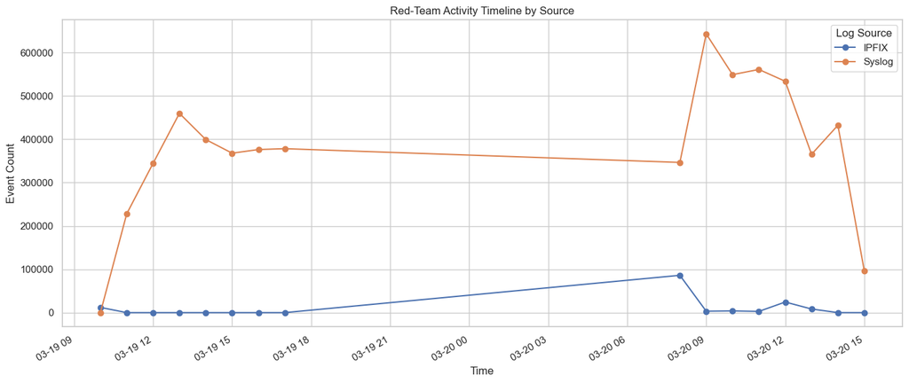

```python
# Plot Red-Team Activity Timeline
activity_timeline = (
    redteam_events.set_index("time")
    .groupby([pd.Grouper(freq="1h"), "source"])
    .size()
    .unstack(fill_value=0)
)

activity_timeline.plot(figsize=(14, 6), marker="o")
plt.title("Red-Team Activity Timeline by Source")
plt.xlabel("Time")
plt.ylabel("Event Count")
plt.grid(True)
plt.legend(title="Log Source")
plt.tight_layout()
plt.show()
```

Explanation: This combined timeline overlays the hourly counts of Red‑Team events from each source—IPFIX (blue) and Syslog (orange) in one chart:

Sustained Log Noise: Syslog entries then surge dramatically, capturing the bulk of reconnaissance and attack noise across SSH, DNS, and other services.

Day 2 Similarity: The pattern repeats on Day 2 with slightly shifted timing, showing consistency in attack tactics.

this plot illustrates the sequence of adversary actions—network footprints preceding the higher‑volume.

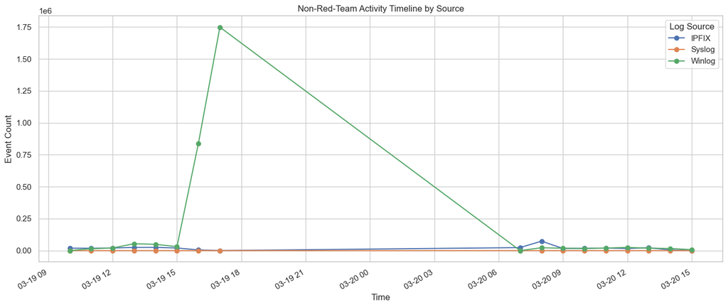

```python
# Plot Non-Red-Team Activity Timeline

# Filter non-redteam rows in each dataset
ipfix_nonred = (
    df_ipfix_clean[~df_ipfix_clean["involves_red"]]
    .loc[:, ["time", "sourceIPv4Address", "destinationIPv4Address"]]
    .assign(source="IPFIX", message="Flow not involving Red-Team IP")
)

syslog_nonred = (
    df_syslog_clean[~df_syslog_clean["mentions_red_ip"]]
    .loc[:, ["time", "message"]]
    .assign(source="Syslog", sourceIPv4Address=None, destinationIPv4Address=None)
)

winlog_nonred = (
    df_winlog_clean[~df_winlog_clean["mentions_red_ip"]]
    .loc[:, ["time", "xml"]]
    .rename(columns={"xml": "message"})
    .assign(source="Winlog", sourceIPv4Address=None, destinationIPv4Address=None)
)

# Combine
nonred_events = pd.concat([ipfix_nonred, syslog_nonred, winlog_nonred], ignore_index=True).sort_values("time")

# Plot
nonred_timeline = (
    nonred_events.set_index("time")
    .groupby([pd.Grouper(freq="1h"), "source"])
    .size()
    .unstack(fill_value=0)
)

nonred_timeline.plot(figsize=(14, 6), marker="o")
plt.title("Non-Red-Team Activity Timeline by Source")
plt.xlabel("Time")
plt.ylabel("Event Count")
plt.grid(True)
plt.legend(title="Log Source")
plt.tight_layout()
plt.show()
```

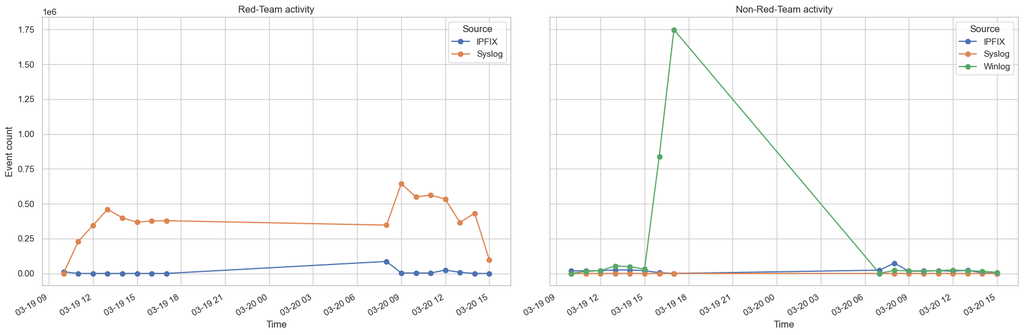

```python
# Side-by-side Comparison of Activity Timelines
fig, axes = plt.subplots(nrows=1, ncols=2, figsize=(18, 6), sharey=True)

activity_timeline.plot(ax=axes[0], marker="o", title="Red-Team activity")
axes[0].set_xlabel("Time")
axes[0].set_ylabel("Event count")
axes[0].grid(True)
axes[0].legend(title="Source")

nonred_timeline.plot(ax=axes[1], marker="o", title="Non-Red-Team activity")
axes[1].set_xlabel("Time")
axes[1].grid(True)
axes[1].legend(title="Source")

plt.tight_layout()
plt.show()
```

Explanation: In this dual-panel view, we place Red‑Team and Non‑Red‑Team activity side by side for direct comparison

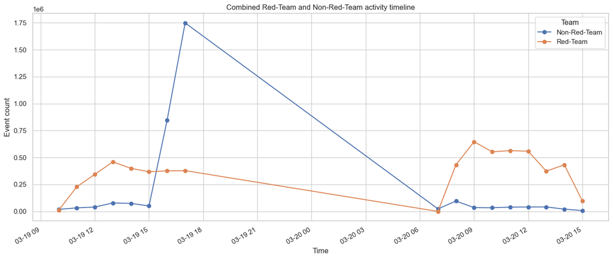

```python
# Overlay Red-Team and Non-Red-Team Activity Timeline
combined = (
    pd.concat([
        redteam_events.assign(team="Red-Team"),
        nonred_events.assign(team="Non-Red-Team")
    ])
    .set_index("time")
    .groupby([pd.Grouper(freq="1h"), "team"])
    .size()
    .unstack(fill_value=0)
)

combined.plot(figsize=(14, 6), marker="o")
plt.title("Combined Red-Team and Non-Red-Team activity timeline")
plt.xlabel("Time")
plt.ylabel("Event count")
plt.grid(True)
plt.legend(title="Team")
plt.tight_layout()
plt.show()
```

```python
# Red-Team Activity Severity Overlay
# Only Winlog has severity levels (via 'level' column)
if "level" in df_winlog_clean.columns:
    df_red_severity = df_winlog_clean[
        (df_winlog_clean["mentions_red_ip"] | df_winlog_clean["red_host"]) & df_winlog_clean["level"].notna()
    ].copy()


    df_red_severity["level"] = pd.to_numeric(df_red_severity["level"], errors="coerce")

    if not df_red_severity.empty:
        severity_overlay = (
            df_red_severity.set_index("time")
            .groupby([pd.Grouper(freq="1h"), "level"])
            .size()
            .unstack(fill_value=0)
        )

        if not severity_overlay.empty:
            severity_overlay.plot(figsize=(14, 6), marker="o")
            plt.title("Red-Team activity severity timeline (Winlog)")
            plt.xlabel("Time")
            plt.ylabel("Event count by severity level")
            plt.grid(True)
            plt.legend(title="Severity level")
            plt.tight_layout()
            plt.show()
        else:
            print("No severity data found to plot.")
    else:
        print("No red-team severity entries found in Winlog.")
else:
    print("No 'level' column available in Winlog data.")
```

```
No red-team severity entries found in Winlog.
```

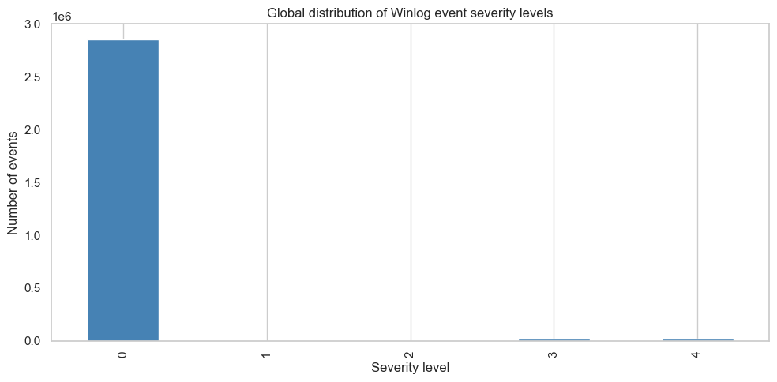

```
Event counts per severity level:
```

```
level
0    2859456
1         13
2        962
3      20761
4      19962
Name: count, dtype: int64
```

```python
# Global Distribution of Winlog Severity Levels

# Ensure 'level' is numeric
df_winlog_clean["level"] = pd.to_numeric(df_winlog_clean["level"], errors="coerce")

# Drop NaNs and count frequency
severity_counts = df_winlog_clean["level"].dropna().value_counts().sort_index()

# Bar plot
severity_counts.plot(kind="bar", figsize=(10, 5), color="steelblue")
plt.title("Global distribution of Winlog event severity levels")
plt.xlabel("Severity level")
plt.ylabel("Number of events")
plt.grid(axis="y")
plt.tight_layout()
plt.show()

# Display raw counts
print("Event counts per severity level:")
display(severity_counts)
```

[figure not shown]

```python
# Overlay Winlog Severity on Combined Timeline

# Filter Winlog entries with valid level and time
df_severity_ts = df_winlog_clean[df_winlog_clean["level"].notna()].copy()
df_severity_ts["level"] = pd.to_numeric(df_severity_ts["level"], errors="coerce")

# Aggregate: severity level count per hour
severity_by_hour = (
    df_severity_ts.set_index("time")
    .groupby([pd.Grouper(freq="1h"), "level"])
    .size()
    .unstack(fill_value=0)
)

# Plot
fig, ax1 = plt.subplots(figsize=(14, 6))

# Plot combined red/non-red activity
combined.plot(ax=ax1, marker="o", linewidth=2)
ax1.set_ylabel("Event Count (Red vs. Non-Red)")
ax1.set_title("Combined activity timeline with Winlog severity overlay")
ax1.grid(True)

# Create secondary axis
ax2 = ax1.twinx()

# Overlay severity bars (stacked)
severity_by_hour.plot(
    ax=ax2,
    kind="bar",
    stacked=True,
    alpha=0.3,
    width=1.0,
    legend=False,
    color=plt.cm.Reds(np.linspace(0.4, 1, severity_by_hour.shape[1]))
)
ax2.set_ylabel("Winlog events by severity level")
ax2.set_ylim(top=max(severity_by_hour.sum(axis=1).max() * 1.2, 10))  # give some headroom

# Legend fix
handles, labels = ax1.get_legend_handles_labels()
handles2, labels2 = ax2.get_legend_handles_labels()
ax1.legend(handles + handles2, labels + labels2, title="Legend", loc="upper left")

plt.tight_layout()
plt.show()
```

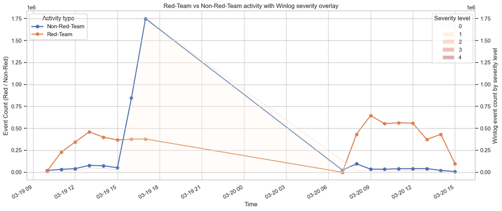

```python
# Enhanced Overlay: Red-Team vs Non-Red + Winlog Severity

# Recalculate severity overlay for Winlog
df_severity_ts = df_winlog_clean[df_winlog_clean["level"].notna()].copy()
df_severity_ts["level"] = pd.to_numeric(df_severity_ts["level"], errors="coerce")

severity_by_hour = (
    df_severity_ts.set_index("time")
    .groupby([pd.Grouper(freq="1h"), "level"])
    .size()
    .unstack(fill_value=0)
)

# Prepare plot
fig, ax1 = plt.subplots(figsize=(14, 6))

# Plot Red-Team vs Non-Red-Team activity as lines
combined.plot(ax=ax1, marker='o', linewidth=2)
ax1.set_ylabel("Event Count (Red / Non-Red)")
ax1.set_title("Red-Team vs Non-Red-Team activity with Winlog severity overlay")
ax1.grid(True)
ax1.set_xlabel("Time")

# Create second y-axis for severity levels
ax2 = ax1.twinx()

# Plot severity as stacked area plot (soft color, transparent)
severity_by_hour.plot.area(
    ax=ax2,
    stacked=True,
    alpha=0.3,
    linewidth=0,
    cmap="OrRd"
)

ax2.set_ylabel("Winlog event count by severity level")

# Custom legend with separation
h1, l1 = ax1.get_legend_handles_labels()
h2, l2 = ax2.get_legend_handles_labels()

# Position legends clearly
first_legend = ax1.legend(h1, l1, title="Activity type", loc="upper left")
second_legend = ax2.legend(h2, l2, title="Severity level", loc="upper right")
ax1.add_artist(first_legend)

plt.tight_layout()
plt.show()
```

```python
print("Unique severity levels in Winlog:")
print(df_winlog_clean["level"].dropna().unique())
```

```
Unique severity levels in Winlog:
[4 3 0 2 1]
```

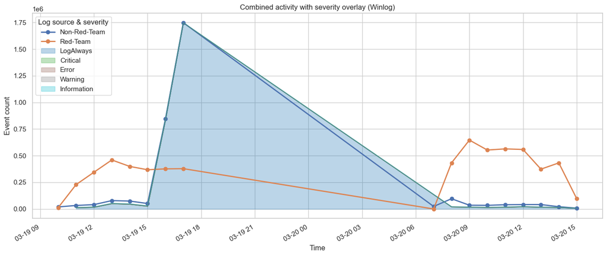

```python
# Map severity levels to human-friendly labels
severity_labels = {
    0: "LogAlways",
    1: "Critical",
    2: "Error",
    3: "Warning",
    4: "Information"
}

# Rename columns
severity_by_hour.columns = severity_by_hour.columns.map(severity_labels)

# Plot with better colormap and legend title
fig, ax = plt.subplots(figsize=(14, 6))
combined.plot(ax=ax, marker="o", linewidth=2, legend=True)
severity_by_hour.plot.area(ax=ax, alpha=0.3, cmap="tab10")

plt.title("Combined activity with severity overlay (Winlog)")
plt.xlabel("Time")
plt.ylabel("Event count")
plt.grid(True)
plt.legend(title="Log source & severity", loc="upper left")
plt.tight_layout()
plt.show()
```

This combined view helps pinpoint precisely when and how Windows hosts registered notable events—critical for assessing whether the exercise’s Windows side generated meaningful alerts or if further tuning is needed to surface real threats

```python
# Use numeric column if not already
df_winlog_clean["level"] = pd.to_numeric(df_winlog_clean["level"], errors="coerce")

# Drop rows with level 0 (LogAlways) and NaN
df_severity = df_winlog_clean[df_winlog_clean["level"].notna() & (df_winlog_clean["level"] != 0)].copy()

# Add hourly column
df_severity["hour"] = df_severity["time"].dt.floor("h")

# Find most common severity level per hour (excluding level 0)
top_severity_per_hour = (
    df_severity.groupby("hour")["level"]
    .agg(lambda x: x.value_counts().idxmax())
    .rename("most_frequent_level")
    .reset_index()
)

# Map level to labels
severity_labels = {
    1: "Critical",
    2: "Error",
    3: "Warning",
    4: "Information"
}
top_severity_per_hour["label"] = top_severity_per_hour["most_frequent_level"].map(severity_labels)

print("Most frequent severity per hour (excluding LogAlways):")
display(top_severity_per_hour.head())
```

```
Most frequent severity per hour (excluding LogAlways):
```

|  | hour | most_frequent_level | label |
| --- | --- | --- | --- |
| 0 | 2019-03-19 11:00:00+01:00 | 3 | Warning |
| 1 | 2019-03-19 12:00:00+01:00 | 4 | Information |
| 2 | 2019-03-19 13:00:00+01:00 | 4 | Information |
| 3 | 2019-03-19 14:00:00+01:00 | 4 | Information |
| 4 | 2019-03-19 15:00:00+01:00 | 4 | Information |

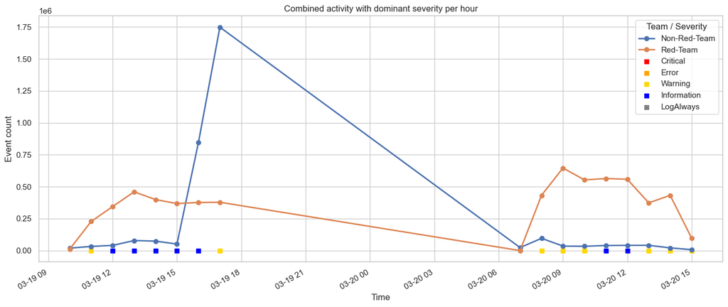

```python
# Reuse the combined timeline
fig, ax = plt.subplots(figsize=(14, 6))

combined.plot(ax=ax, marker="o", linewidth=2)

# Plot top severity level as scatter points
colors = {
    "Critical": "red",
    "Error": "orange",
    "Warning": "gold",
    "Information": "blue",
    "LogAlways": "gray"
}

for level_label, color in colors.items():
    points = top_severity_per_hour[top_severity_per_hour["label"] == level_label]
    ax.scatter(points["hour"], [0]*len(points), label=level_label, color=color, s=40, marker="s")

plt.title("Combined activity with dominant severity per hour")
plt.xlabel("Time")
plt.ylabel("Event count")
plt.grid(True)
plt.legend(title="Team / Severity")
plt.tight_layout()
plt.show()
```

Plot the overall activity lines for Red‑Team (orange) and non‑Red‑Team (blue).

Scatter square markers at zero for each hour’s top severity label—colored red for Critical, orange for Error, gold for Warning, blue for Information, and gray for LogAlways.

Severity markers on the time axis, we can instantly see severity levels during each time window, contextualizing flow and log volumes with the gravity of Windows‑side events. Removed LogAlways so that it doesnt hide the others.

# Summary and Next Steps

**Future Analysis Ideas**

1. **Protocol‑Level Breakdown**
   - Drill into IPFIX application protocols (DNS, SSH, HTTP) to see exactly what services were targeted.
2. **Anomaly Detection**
   - Build statistical or ML models to detect deviations from normal traffic and log baselines.
3. **Cross‑Dataset Correlation**
   - Link IPFIX flows, syslog, and Winlog entries by shared session IDs or tight time windows to trace multi‑stage attacks.
4. **Windows XML Deep‑Dive**
   - Parse additional XML fields (EventID, Task, Keywords) to uncover hidden Windows alerts tied to adversary actions.

*End of notebook.*